# logistic_regression(binomial_regression)_and_regularization

Back

## Some clarifications

- In statistics, the logistic model (or logit model) is a widely used statistical model that, in its basic form, uses a [logistic function](https://en.wikipedia.org/wiki/Logistic_function) to model a binary dependent variable; many more complex [extensions](https://en.wikipedia.org/wiki/Logistic_regression#Extensions) exist;
- In regression analysis, logistic regression (or logit regression) is estimating the parameters of a logistic model; it is a form of binomial regression. Mathematically, a binary logistic model has a dependent variable with two possible values, such as pass/fail, win/lose, alive/dead or healthy/sick; these are represented by an indicator variable, where the two values are labeled "0" and "1";
- In the logistic model, the [log-odds](https://en.wikipedia.org/wiki/Log-odds) (the logarithm of the odds) for the value labeled "1" is a linear combination of one or more independent variables ("predictors"); the independent variables can each be a binary variable (two classes, coded by an indicator variable) or a continuous variable (any real value). The corresponding probability of the value labeled "1" can vary between 0 (certainly the value "0") and 1 (certainly the value "1"), hence the labeling; the function that converts log-odds to probability is the logistic function, hence the name;
- The [unit of measurement](https://en.wikipedia.org/wiki/Unit_of_measurement) for the log-odds scale is called a [logit](https://en.wikipedia.org/wiki/Logit), from **log**istic un**it**, hence the alternative names;
- Analogous models with a different sigmoid function instead of the logistic function can also be used, such as the [probit model](https://en.wikipedia.org/wiki/Probit_model); the defining characteristic of the logistic model is that increasing one of the independent variables multiplicatively scales the odds of the given outcome at a constant rate, with each dependent variable having its own parameter; for a binary independent variable this generalizes the [odds ratio](https://en.wikipedia.org/wiki/Odds_ratio);
- Logistic regression was developed by statistician David Cox in 1958. The binary logistic regression model has [extensions](https://en.wikipedia.org/wiki/Logistic_regression#Extensions) to more than two levels of the dependent variable: categorical outputs with more than two values are modelled by [multinomial logistic regression](https://en.wikipedia.org/wiki/Multinomial_logistic_regression), and if the multiple categories are [ordered](https://en.wikipedia.org/wiki/Level_of_measurement#Ordinal_type), by [ordinal logistic regression](https://en.wikipedia.org/wiki/Ordinal_logistic_regression), for example the proportional odds ordinal logistic model. The model itself simply models probability of output in terms of input, and does not perform [statistical classification](https://en.wikipedia.org/wiki/Statistical_classification) (it is not a classifier), though it can be used to make a classifier, for instance by choosing a cutoff value and classifying inputs with probability greater than the cutoff as one class, below the cutoff as the other; this is a common way to make a binary classifier. The coefficients are generally not computed by a closed-form expression, unlike linear least squares); see [§ Model fitting](https://en.wikipedia.org/wiki/Logistic_regression#Model_fitting);

## Modeling

Lets look back the [linear regression](https://lnshi.github.io/ml-exercises/ml_basics_in_html/rdm001_multivariable_linear_regression_gradient_descent/multivariable_linear_regression_gradient_descent.html#Define-the-latest-squares-cost-function) a bit, for linear regression its [link function](https://en.wikipedia.org/wiki/Generalized_linear_model#Link_function) is a multivariate linear equation:

$$ z_\theta(x_1, x_2, \dots, x_m) = \theta_0 + \theta_1x_1 + \dots + \theta_mx_m \ = \theta \ \begin{pmatrix} 1 & x_1 & x_2 & \dots & x_m \end{pmatrix} , \, \ \theta = \ \begin{pmatrix} \theta_0 \\ \theta_1 \\ \vdots \\ \theta_m \end{pmatrix} $$

for logistic regression it is a [generalized linear model (GLM)](https://en.wikipedia.org/wiki/Generalized_linear_model) also, and its [link function](https://en.wikipedia.org/wiki/Generalized_linear_model#Link_function) is [sigmoid function](https://en.wikipedia.org/wiki/Sigmoid_function): $y = \frac{1}{1 + e^{-x}}$, then we can define the model for logistic regression:

$$ h_\theta(x) = h_\theta(x_1, x_2, \dots, x_m) = \frac{1}{1 + e^{-\theta \begin{pmatrix} 1 & x_1 & x_2 & \dots & x_m \end{pmatrix}}} \ , \, \ \theta = \ \begin{pmatrix} \theta_0 \\ \theta_1 \\ \vdots \\ \theta_m \end{pmatrix} $$

✅ Find more details about why the link function for linear regression is 'a multivariate linear equation', and for logistic is sigmoid function from this topic: [rdm008_GLM_and_exponential_family_distributions](https://lnshi.github.io/ml-exercises/ml_basics_in_html/rdm008_GLM_and_exponential_family_distributions/GLM_and_exponential_family_distributions.html)

#### Lets see what does the sigmoid function do

- Lets draw the sigmoid function

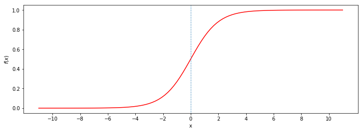

```python
import numpy as np
import matplotlib.pyplot as plt
%matplotlib inline

def f(x):
    return 1 / (1 + np.power(np.e, -x))

x = np.linspace(-11., 11., num=100, endpoint=True,)

fig, ax = plt.subplots(figsize=(12, 4))
ax.plot(x, f(x), 'r')
ax.set_xticks(np.linspace(-10., 10., num=11, endpoint=True), minor=False)
ax.set_xlabel('x')
ax.set_ylabel('$f(x)$')

vline = ax.axvline(x=0.)
vline.set_linestyle('dotted')
vline.set_linewidth(1.3)
```

- Analysis
  - The domain of the sigmoid function is: $(-\infty, +\infty)$, and the range is: $(0, 1)$;
  - So the range of the above function: $h_\theta(x)$ is also $(0, 1)$;
  - Then the value of the above function: $h_\theta(x)$ can represent some kind of probability, like:
    - If $h_\theta(x) < 0.5$ then the sample $x$ belongs to class A;
    - If $h_\theta(x) > 0.5$ then the sample $x$ belongs to calss B;
    - So we can treat the sigmoid function as the PDF (probability density function)) of the ALL sample dataset X;

#### How to estimate the $\theta$: [MLE (Maximum Likelihood Estimation)](https://lnshi.github.io/ml-exercises/ml_basics_in_html/rdm006_Bayes%E2%80%99%20Theorem_and_MLE_MAP/Bayes%E2%80%99%20Theorem_and_MLE_MAP.html)

- We can see the value of the above function: $h_\theta(x)$ represents the probability of that $h_\theta(x) = 1$, so to input $x$, the probability of $h_\theta(x) = 1$ or $h_\theta(x) = 0$ is:
  - $h_\theta(x) = 1$ (belongs to class 1): $P(Y=1|x; \theta) = h_\theta(x)$;
  - $h_\theta(x) = 0$ (belongs to class 0): $P(Y=0|x; \theta) = 1 - h_\theta(x)$;
  - That is: discrete variable $Y$ ($x$ belongs to class 0 or 1) subjects to [bernoulli distribution](https://en.wikipedia.org/wiki/Bernoulli_distribution), then we can get its PMF (probability mass function)):

$$ P(Y|x; \theta) = [h_\theta(x)]^Y[1 - h_\theta(x)]^{1 - Y} $$

Note

Here I used capital $Y$, it corresponds to each $y^{(i)} (i = 1, 2, \dots, n)$ in the sample dataset $X$, but due to the fact that sometimes for the given sample dataset $X$ the $y^{(i)} = h_\theta(x_1^{(i)}, x_2^{(i)}, \dots, x_m^{(i)}) \not\in \{0, 1\}$, then for binomial regression we need to normalize it to 0 or 1 according to some rules, so here I use capital $Y$ to represent the normalized $y^{(i)} (i = 1, 2, \dots, n)$.

In the latter part of this notebook, I will use back $y^{(i)} (i = 1, 2, \dots, n)$ for standardization purpose, but you need to remember: the only allowed value for $y^{(i)} = h_\theta(x_1^{(i)}, x_2^{(i)}, \dots, x_m^{(i)})$ is 0 or 1, if it is NOT, then you need to do the nomalization first.

- Since each sample point in $X$ is independent to each other, then we can tell $X$'s [Joint probability distribution](https://en.wikipedia.org/wiki/Joint_probability_distribution) as:

$$ \begin{align*} J(\theta) &= \prod_{i = 1}^{n}P(y^{(i)}|x^{(i)}; \theta) \\ &= \prod_{i = 1}^{n}[h_\theta(x^{(i)})]^{y^{(i)}}[1 - h_\theta(x^{(i)})^{1 - y^{(i)}}] \\ \textbf{ log-it} \\ \Rightarrow j(\theta) &= log(J(\theta)) = ln(J(\theta)) = ln\big(\prod_{i = 1}^{n}[h_\theta(x^{(i)})]^{y^{(i)}}[1 - h_\theta(x^{(i)})^{1 - y^{(i)}}]\big) \\ &= \sum_{i = 1}^{n} ln[h_\theta(x^{(i)})]^{y^{(i)}} + ln[1 - h_\theta(x^{(i)})]^{1 - y^{(i)}} \\ &= \sum_{i = 1}^{n} y^{(i)}ln[h_\theta(x^{(i)})] + (1 - y^{(i)})ln[1 - h_\theta(x^{(i)})] \end{align*} $$

- [MLE (Maximum Likelihood Estimation)](https://lnshi.github.io/ml-exercises/ml_basics_in_html/rdm006_Bayes%E2%80%99%20Theorem_and_MLE_MAP/Bayes%E2%80%99%20Theorem_and_MLE_MAP.html) tries to find out the $\theta$ to maximize the above $j(\theta)$, we can use the gradient ASCENT algorithm, but if we do a small transformation then we can use the [gradient descent algorithm](https://lnshi.github.io/ml-exercises/ml_basics_in_html/rdm002_gradient_and_gradient_descent/gradient_and_gradient_descent.html):

$$ l(\theta) = -\frac{1}{n}j(\theta) $$

- **Conclusion: so the task to estimate the $\theta$ is: finding out the $\theta$ to minimize the value of the above function $l(\theta)$ with gradient descent algorithm!**

## Run through with real example

```python
import os

import numpy as np
import pandas as pd
import matplotlib.pyplot as plt

# Sets the backend of matplotlib to the 'inline' backend.
#
# With this backend, the output of plotting commands is displayed inline within frontends like the Jupyter notebook,
# directly below the code cell that produced it.
# The resulting plots will then also be stored in the notebook document.
#
# More details: https://stackoverflow.com/questions/43027980/purpose-of-matplotlib-inline
%matplotlib inline
```

#### Read the data in, and then show the first several rows

```python
path = os.getcwd() + '/data.csv'
data = pd.read_csv(path, sep=',', header=0)
data.head()
```

|  | Exam 1 | Exam 2 | Admitted |
| --- | --- | --- | --- |
| 0 | 34.623660 | 78.024693 | 0 |
| 1 | 30.286711 | 43.894998 | 0 |
| 2 | 35.847409 | 72.902198 | 0 |
| 3 | 60.182599 | 86.308552 | 1 |
| 4 | 79.032736 | 75.344376 | 1 |

As you can see, we have two independent continuous variables: `Exam 1` and `Exam 2`, and we want to predict the binomial result `Admitted` base on them: 0 → `unadmitted`, 1 → `admitted`.

#### Lets visualise the sample dataset with scatter plot

```
Text(0,0.5,'Exam 2 Score')
```

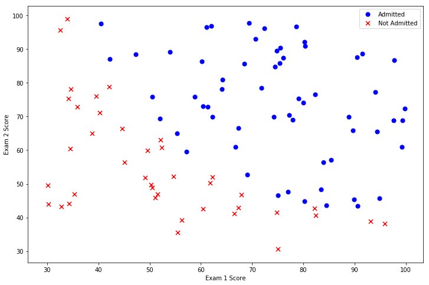

```python
positive = data[data['Admitted'].isin([1])]
negative = data[data['Admitted'].isin([0])]

fig, ax = plt.subplots(figsize=(12,8))
ax.scatter(positive['Exam 1'], positive['Exam 2'], s=50, c='b', marker='o', label='Admitted')
ax.scatter(negative['Exam 1'], negative['Exam 2'], s=50, c='r', marker='x', label='Not Admitted')
ax.legend()
ax.set_xlabel('Exam 1 Score')
ax.set_ylabel('Exam 2 Score')
```

#### Data preprocessing and 'features data' / 'target variable' split

```python
# Add a 'ones' column.
data.insert(0, 'Ones', 1)
```

```python
# Set X (features data) and y (target variable).
cols = data.shape[1]
X = data.iloc[:, 0:cols-1].values
y = data.iloc[:, cols-1:cols].values

# Initalize the parameters array theta.
theta = np.zeros(cols - 1)
```

#### Always pay attention to the shape of the matrixes to get around of some unnecessary troubles.

```python
X.shape, y.shape, theta.shape
```

```
((100, 3), (100, 1), (3,))
```

#### Define the sigmoid function

```python
def sigmoid(x):
    return 1 / (1 + np.exp(-x))
```

#### Define the cost function

```python
def cost(theta, X, y):
    theta = np.reshape(theta, (-1, len(theta)))

    assert X.shape[1] == theta.shape[1], \
      'Improper shape of theta, expected to be: {}, actual: {}'.format((1, X.shape[1]), theta.shape)

    # Numpy np.multiply vs *-Operator:
    #   https://stackoverflow.com/questions/49493482/numpy-np-multiply-vs-operator
    # There is no difference. However, the np.multiply function can take in additional,
    #   optional arguments, making it more versatile.
    part0 = np.multiply(y, np.log(sigmoid(X @ theta.T)))
    part1 = np.multiply(1 - y, np.log(1 - sigmoid(X @ theta.T)))

    return -np.sum(part0 + part1) / len(X)
```

#### Lets check the initial cost

```python
cost(theta, X, y)
```

```
0.6931471805599453
```

#### Lets define the gradient

- [What is gradient?](https://lnshi.github.io/ml-exercises/ml_basics_in_html/rdm002_gradient_and_gradient_descent/gradient_and_gradient_descent.html#Derivative-and-partial-derivative)
- Partial derivative of $l(\theta)$ to $\theta_i$

$$ \begin{align*} \because\, j(\theta) &= \sum_{i = 1}^{n} y^{(i)}ln[h_\theta(x^{(i)})] + (1 - y^{(i)})ln[1 - h_\theta(x^{(i)})] \\ &= \sum_{i = 1}^{n} y^{(i)}ln[h_\theta(x^{(i)})] - y^{(i)}ln[1 - h_\theta(x^{(i)})] + ln[1 - h_\theta(x^{(i)})] \\ &= \sum_{i = 1}^{n} y^{(i)}ln\frac{h_\theta(x^{(i)})}{1 - h_\theta(x^{(i)})} + ln[1 - h_\theta(x^{(i)})] \\ &= \sum_{i = 1}^{n} y^{(i)}ln\frac{\frac{1}{1 + e^{-\theta x^{(i)}}}}{1 - \frac{1}{1 + e^{-\theta x^{(i)}}}} + ln[1 - h_\theta(x^{(i)})] \\ &= \sum_{i = 1}^{n} y^{(i)}ln\frac{1}{e^{-\theta x^{(i)}}} + ln[1 - h_\theta(x^{(i)})] \\ &= \sum_{i = 1}^{n} -y^{(i)}lne^{-\theta x^{(i)}} + ln[1 - h_\theta(x^{(i)})] \\ &= \sum_{i = 1}^{n} y^{(i)}\theta x^{(i)} + ln[1 - h_\theta(x^{(i)})] \\ \\ \because\, 1 - h_\theta(x) &= \frac{e^{-\theta x}}{1 + e^{-\theta x}} \\ &\Rightarrow \frac{\partial}{\partial \theta} h_\theta(x) \ = -\frac{-x e^{-\theta x}}{(1 + e^{-\theta x})^2} \ = x \frac{e^{-\theta x}}{1 + e^{-\theta x}} \frac{1}{1 + e^{-\theta x}} \ = x [1 - h_\theta(x)] h_\theta(x) \\ &\Rightarrow \frac{\partial}{\partial \theta}ln[1 - h_\theta(x)] \ = \frac{1}{1 - h_\theta(x)} (-\frac{\partial}{\partial \theta} h_\theta(x)) \ = -x h_\theta(x) \\ \\ \therefore\, \frac{\partial}{\partial \theta_i}j(\theta) \ &= \sum_{i = 1}^{n} [y^{(i)} x^{(i)} - x^{(i)} h_\theta(x^{(i)})] \ = \sum_{i = 1}^{n} [y^{(i)} - h_\theta(x^{(i)})]x^{(i)} \\ \\ \therefore\, \frac{\partial}{\partial \theta_i} l(\theta) \ &= \frac{1}{n} \sum_{i = 1}^{n} [h_\theta(x^{(i)}) - y^{(i)}]x^{(i)} \end{align*} $$

```python
def gradient(theta, X, y):
    theta = np.reshape(theta, (-1, len(theta)))

    assert X.shape[1] == theta.shape[1], \
      'Improper shape of theta, expected to be: {}, actual: {}'.format((1, X.shape[1]), theta.shape)

    parameters = int(theta.shape[1])
    grad = np.zeros(parameters)
    error = sigmoid(X @ theta.T) - y

    for i in range(parameters):
        term = np.multiply(error, X[:, [i]])
        grad[i] = np.sum(term) / len(X)

    return grad
```

#### Experience [scipy.optimize.fmin_tnc](https://docs.scipy.org/doc/scipy-0.14.0/reference/generated/scipy.optimize.fmin_tnc.html)

As you noted: we didn't define the gradient descent algorithm but the gradient) only, lets try to use the [fminunc, Octave function](https://octave.org/doc/v4.0.1/Minimizers.html) to achieve the same effect like gradient descent.

```python
import scipy.optimize as opt

result = opt.fmin_tnc(func=cost, x0=theta, fprime=gradient, args=(X, y))
cost(result[0], X, y)
```

```
0.20349770158947444
```

#### Lets define the `predict` function with the $\theta$ we learned and check the total prediction accuracy

```python
def predict(theta, X):
    theta = np.reshape(theta, (-1, len(theta)))

    assert X.shape[1] == theta.shape[1], \
      'Improper shape of theta, expected to be: {}, actual: {}'.format((1, X.shape[1]), theta.shape)

    probabilities = sigmoid(X @ theta.T)

    return [1 if p >= 0.5 else 0 for p in probabilities]
```

```python
predictions = predict(result[0], X)

r_or_w = []
for (a, b) in zip(predictions, y):
    if (a == 1 and b[0] == 1) or (a == 0 and b[0] == 0):
        r_or_w.append(1)
    else:
        r_or_w.append(0)

accuracy = float(sum(r_or_w)) / len(r_or_w) * 100

print('Total accuracy: {0:.2f}%'.format(accuracy))
```

```
Total accuracy: 89.00%
```

## Regularized logistic regression

#### Norm)

Vector

- **0-norm**: number of the non-zero components;
- **1-norm**: sum of the absolute values of the components: $$||x||_1 = \sum_{i = 1}^{n}|x_i|$$
- **2-norm**: euclidean norm, represents the magnitude/length of the vector: $$||x||_2 = \sqrt{\sum_{i = 1}^{n}x_i^2}$$
- **$\infty$-norm**: the maximum absolute value of the components: $$||x||_{\infty} = max(|x_1|, |x_2|, \dots, |x_n|)$$
- **$-\infty$-norm**: the minimum absolute of the components: $$||x||_{-\infty} = min(|x_1|, |x_2|, \dots, |x_n|)$$
- **p-norm**: $$||x||_p = (\sum_{i = 1}^{n}|x_i|^p)^{\frac{1}{p}}$$

Matrix($X$, m X n, m rows and n columns)

- Matrix norm)

#### Regularization

Different types of fittings:

[figure not shown]

Analysis:

- Any function can be approached by a combination of polynomials: [Taylor series](https://en.wikipedia.org/wiki/Taylor_series)
- For easier telling, we take this function as example: $f_\theta(x) = \theta_0 + \theta_1x_1 + \theta_2x_2 + \dots + \theta_mx_m$
- Over-fitting is because we had too many **non-zero** components in the vector $\theta$ (note: this is the 0-norm of the vector $\theta$), that is: the model tryies too much to approach the boundary;
- Like in above 'Over-fitting' graph, i tagged two parts of the model with **black dot**, if we can make its corresponding coefficients in the fitting polynomials to be 0 or a small enough number, then we can eliminate/weaken its influence to the model, that is: making the model approach 'Appropriate-fitting' from 'Over-fitting';
- From the [gradient descent algorithm](https://lnshi.github.io/ml-exercises/ml_basics_in_html/rdm002_gradient_and_gradient_descent/gradient_and_gradient_descent.html#Gradient-descent-algorithm) we know we always decrease all the $\theta_i (i = 0, 1, \dots, m)$ in one round; So if we add one **positive** item to the cost function, like for logistic regression, we change the cost function

  from: $$ \begin{align*} l(\theta) &= -\frac{1}{n}j(\theta) \\ &= -\frac{1}{n}\sum_{i = 1}^{n} y^{(i)}ln[h_\theta(x^{(i)})] + (1 - y^{(i)})ln[1 - h_\theta(x^{(i)})] \end{align*} $$

  to: $$ \begin{align*} l(\theta) &= -\frac{1}{n}j(\theta) + \frac{\lambda}{2n}\sum_{i = 1}^{m}\theta_i^2 \\ &= -\frac{1}{n}\sum_{i = 1}^{n} y^{(i)}ln[h_\theta(x^{(i)})] + (1 - y^{(i)})ln[1 - h_\theta(x^{(i)})] + \frac{\lambda}{2n}\sum_{i = 1}^{m}\theta_i^2 \\ \big(&\frac{\lambda}{2n}\sum_{i = 1}^{m}\theta_i^2 \textbf{ is called the regularization item}\big) \end{align*} $$

  that is for the new regularized gradient algorithm:

  $ \text{repeat until convergence }\Bigg\{ $

  $$ \begin{align*} \theta_0 &= \theta_0 - \alpha\frac{1}{n} \sum_{i = 1}^{n} [h_\theta(x^{(i)}) - y^{(i)}]x_0^{(i)} \\ \theta_1 &= \theta_1 - \alpha\Bigg[\frac{1}{n} \sum_{i = 1}^{n} [h_\theta(x^{(i)}) - y^{(i)}]x_1^{(i)} + \frac{\lambda}{n}\theta_1\Bigg] \\ \vdots \\ \theta_m &= \theta_m - \alpha\Bigg[\frac{1}{n} \sum_{i = 1}^{n} [h_\theta(x^{(i)}) - y^{(i)}]x_m^{(i)} + \frac{\lambda}{n}\theta_m\Bigg] \end{align*} $$

  $ \Bigg\} $

  so then: when we try to minimise the cost function, we need to both minimise the original cost items and the newly added positive regularization items, so kindly like the newly added positive regularization items put a **penalization** to the original cost items: now they need to decrease more, actually it is penalization to each component of the $\theta$, but **note** the regularization item we start from $i = 1$, so no penalization to the $\theta_0$, coz $\theta_0$ corresponds to the the ones column we added;

  also: the noisy samples are alwasy minority in the whole samples dataset, so they should originally have smaller coefficients compare with others, then after the penalization we have chance to eliminate/weaken their influences, that is: making the model approach 'Appropriate-fitting' from 'Over-fitting'!

## Run regularized logistic regression with real example

Lets say we have some wafers' testing scores data('Test 1' scores and 'Test 2' scores) and corresponding acceptance data('Accepted': 0 or 1), and we want to build one model to predict whether a wafer can be accepted or not according to its two test scores.

#### Dataset visualization

```
Text(0,0.5,'Test 2 Score')
```

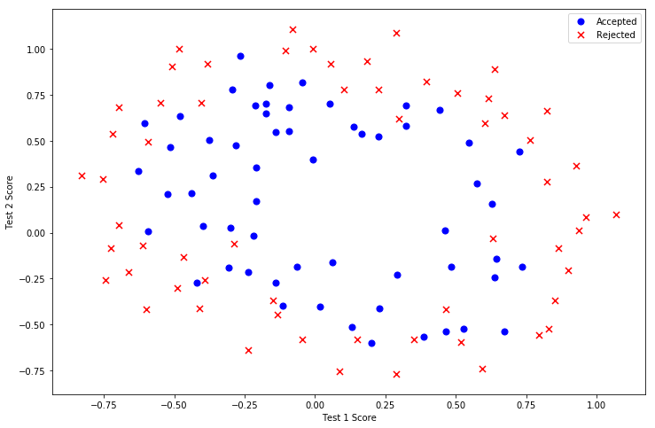

```python
path = os.getcwd() + '/regularized_logistic_regression_data.csv'
data2 = pd.read_csv(path, sep=',', header=0)

positive = data2[data2['Accepted'].isin([1])]
negative = data2[data2['Accepted'].isin([0])]

fig, ax = plt.subplots(figsize=(12,8))
ax.scatter(positive['Test 1'], positive['Test 2'], s=50, c='b', marker='o', label='Accepted')
ax.scatter(negative['Test 1'], negative['Test 2'], s=50, c='r', marker='x', label='Rejected')
ax.legend()
ax.set_xlabel('Test 1 Score')
ax.set_ylabel('Test 2 Score')
```

As you can see from above graph, for this dataset there is **No** linear decision boundary in 2-dimensional space, to solve this kind of classfication problem one way is: we can do polynomial feature expansion/extraction to generate more features from the limited base features (the essence is projecting the sample dataset to higher dimensional space!).

**Conclusion: when a lower dimensional space NOT discriminable dataset is PROJECTED to a PROPER higher dimensional space it always will be discriminable, the boundary is a hyper plane or just a discrimination function.**

#### Question: what are the differences of the 'a hyper plane' or 'a discrimination function' here?

#### Polynomial expansion/extraction to generate more features from the limited base features

#### Question: what are the best practices / skills / underlying theories for the features expansion/extraction?

```python
def expand(dimension):
    data = pd.read_csv(path, sep=',', header=0)
    x1 = data['Test 1']
    x2 = data['Test 2']

    for i in range(1, dimension):
        for j in range(0, i):
            data['F' + str(i) + str(j)] = np.power(x1, i - j) * np.power(x2, j)

    data.drop('Test 1', axis=1, inplace=True)
    data.drop('Test 2', axis=1, inplace=True)

    # Add a 'ones' column.
    data.insert(1, 'Ones', 1)

    return data
```

#### Test to expand to 10-dimensional space

```python
data_10d = expand(5)

data_10d.head()
```

|  | Accepted | Ones | F10 | F20 | F21 | F30 | F31 | F32 | F40 | F41 | F42 | F43 |
| --- | --- | --- | --- | --- | --- | --- | --- | --- | --- | --- | --- | --- |
| 0 | 1 | 1 | 0.051267 | 0.002628 | 0.035864 | 0.000135 | 0.001839 | 0.025089 | 0.000007 | 0.000094 | 0.001286 | 0.017551 |
| 1 | 1 | 1 | -0.092742 | 0.008601 | -0.063523 | -0.000798 | 0.005891 | -0.043509 | 0.000074 | -0.000546 | 0.004035 | -0.029801 |
| 2 | 1 | 1 | -0.213710 | 0.045672 | -0.147941 | -0.009761 | 0.031616 | -0.102412 | 0.002086 | -0.006757 | 0.021886 | -0.070895 |
| 3 | 1 | 1 | -0.375000 | 0.140625 | -0.188321 | -0.052734 | 0.070620 | -0.094573 | 0.019775 | -0.026483 | 0.035465 | -0.047494 |
| 4 | 1 | 1 | -0.513250 | 0.263426 | -0.238990 | -0.135203 | 0.122661 | -0.111283 | 0.069393 | -0.062956 | 0.057116 | -0.051818 |

#### New cost function with regularization item

```python
def cost_reg(theta, X, y, alpha):
    theta = np.reshape(theta, (-1, len(theta)))

    assert X.shape[1] == theta.shape[1], \
      'Improper shape of theta, expected to be: {}, actual: {}'.format((1, X.shape[1]), theta.shape)

    part0 = np.multiply(y, np.log(sigmoid(X @ theta.T)))
    part1 = np.multiply(1 - y, np.log(1 - sigmoid(X @ theta.T)))
    reg = alpha / (2 * len(X)) * np.sum(np.power(theta[:, 1:theta.shape[1]], 2))

    return -np.sum(part0 + part1) / len(X) + reg
```

#### New gradient function with regularization item

```python
def gradient_reg(theta, X, y, alpha):
    theta = np.reshape(theta, (-1, len(theta)))

    assert X.shape[1] == theta.shape[1], \
      'Improper shape of theta, expected to be: {}, actual: {}'.format((1, X.shape[1]), theta.shape)

    parameters = int(theta.shape[1])
    grad = np.zeros(parameters)
    error = sigmoid(X @ theta.T) - y

    for i in range(parameters):
        term = np.multiply(error, X[:, [i]])

        if i == 0:
            # No penalization to theta_0.
            grad[i] = np.sum(term) / len(X)
        else:
            grad[i] = np.sum(term) / len(X) + alpha / len(X) * theta[:, i]

    return grad
```

#### Prepare the 10-d data

```python
data_10d = expand(5)

cols = data_10d.shape[1]
X_10d = data_10d.iloc[:, 1:cols].values
y_10d = data_10d.iloc[:, 0:1].values
theta_10d = np.zeros(cols - 1)

alpha_10d = 0.001

X_10d.shape, y_10d.shape, theta_10d.shape
```

```
((118, 11), (118, 1), (11,))
```

#### Check the initial cost for 10-d

```python
cost_reg(theta_10d, X_10d, y_10d, alpha_10d)
```

```
0.6931471805599454
```

```python
import scipy.optimize as opt

result_10d = opt.fmin_tnc(func=cost_reg, x0=theta_10d, fprime=gradient_reg, args=(X_10d, y_10d, alpha_10d))
result_10d
```

```
(array([  0.46299414,  -1.75190458,  13.85774547,  -5.58210244,
         12.26744383,  13.80034163,   4.41640165, -32.41080116,
         -8.17110088, -37.77933088,   1.52446127]), 89, 1)
```

```python
predictions_10d = predict(result_10d[0], X_10d)

r_or_w = []
for (a, b) in zip(predictions_10d, y_10d):
    if (a == 1 and b[0] == 1) or (a == 0 and b[0] == 0):
        r_or_w.append(1)
    else:
        r_or_w.append(0)

accuracy = float(sum(r_or_w)) / len(r_or_w) * 100

print('Total accuracy: {0:.2f}%'.format(accuracy))
```

```
Total accuracy: 77.12%
```

#### Prepare the 6-d data

```python
data_6d = expand(4)

cols = data_6d.shape[1]
X_6d = data_6d.iloc[:, 1:cols].values
y_6d = data_6d.iloc[:, 0:1].values
theta_6d = np.zeros(cols - 1)

alpha_6d = 0.001

print(X_6d.shape, y_6d.shape, theta_6d.shape)

data_6d.head()
```

```
(118, 7) (118, 1) (7,)
```

|  | Accepted | Ones | F10 | F20 | F21 | F30 | F31 | F32 |
| --- | --- | --- | --- | --- | --- | --- | --- | --- |
| 0 | 1 | 1 | 0.051267 | 0.002628 | 0.035864 | 0.000135 | 0.001839 | 0.025089 |
| 1 | 1 | 1 | -0.092742 | 0.008601 | -0.063523 | -0.000798 | 0.005891 | -0.043509 |
| 2 | 1 | 1 | -0.213710 | 0.045672 | -0.147941 | -0.009761 | 0.031616 | -0.102412 |
| 3 | 1 | 1 | -0.375000 | 0.140625 | -0.188321 | -0.052734 | 0.070620 | -0.094573 |
| 4 | 1 | 1 | -0.513250 | 0.263426 | -0.238990 | -0.135203 | 0.122661 | -0.111283 |

```python
import scipy.optimize as opt

result_6d = opt.fmin_tnc(func=cost_reg, x0=theta_6d, fprime=gradient_reg, args=(X_6d, y_6d, alpha_6d))
result_6d
```

```
(array([ 0.94973349,  0.91404169, -4.38856789, -0.89380604,  0.05127608,
        -0.45579569, -1.98161451]), 37, 1)
```

```python
predictions_6d = predict(result_6d[0], X_6d)

r_or_w = []
for (a, b) in zip(predictions_6d, y_6d):
    if (a == 1 and b[0] == 1) or (a == 0 and b[0] == 0):
        r_or_w.append(1)
    else:
        r_or_w.append(0)

accuracy = float(sum(r_or_w)) / len(r_or_w) * 100

print('Total accuracy: {0:.2f}%'.format(accuracy))
```

```
Total accuracy: 66.10%
```

## Use 'sklearn' directly

```python
from sklearn import linear_model

# Note: it is lowercase alphabet 'l<-L', not digit '1'.
model = linear_model.LogisticRegression(penalty='l1', C=1.0)
model.fit(X_10d, y_10d.ravel())
```

```
LogisticRegression(C=1.0, class_weight=None, dual=False, fit_intercept=True,
          intercept_scaling=1, max_iter=100, multi_class='ovr', n_jobs=1,
          penalty='l1', random_state=None, solver='liblinear', tol=0.0001,
          verbose=0, warm_start=False)
```

```python
model.score(X_10d, y_10d)
```

```
0.652542372881356
```

The accuracy is a bit lower than the one we build from scratch, but keep in mind this result is using the default parameters provided by scikit-learn, thus we can further tune it to achieve better accuracy.

## References

- [机器学习练习（三）——逻辑回归](https://blog.csdn.net/and_w/article/details/52836716)
- [Logistic regression](https://en.wikipedia.org/wiki/Logistic_regression)
- [Logistic Regression（逻辑回归）原理及公式推导](https://blog.csdn.net/programmer_wei/article/details/52072939)
- [Binomial distribution](https://en.wikipedia.org/wiki/Binomial_distribution)
- [Bernoulli distribution](https://en.wikipedia.org/wiki/Bernoulli_distribution)
- [Joint probability distribution](https://en.wikipedia.org/wiki/Joint_probability_distribution)
- Norm (mathematics))
- [Matrix norm](https://en.wikipedia.org/wiki/Matrix_norm)
- [机器学习中常常提到的正则化到底是什么意思？](https://www.zhihu.com/question/20924039)
- [Taylor series](https://en.wikipedia.org/wiki/Taylor_series)